# Simulation MixPCR - sans constante

## Prédictions

- Globalement

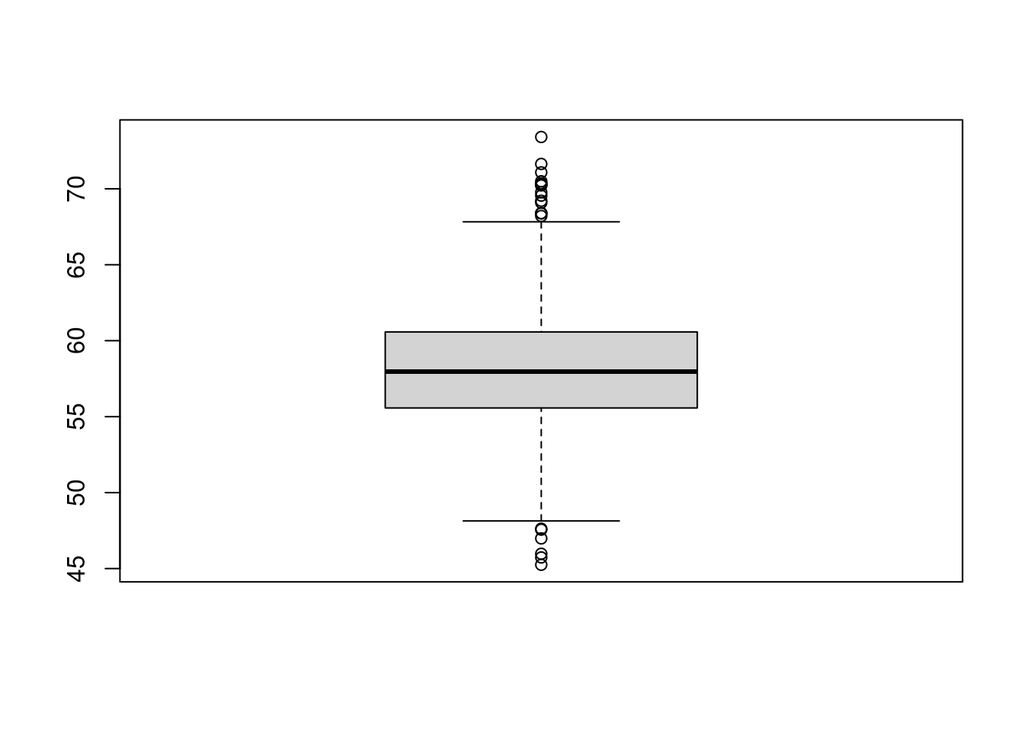

```r
boxplot(res.simu$MSE.pred)
```

L’erreur moyenne sur les prédictions reste dans les mêmes ordres de grandeurs pour toutes les configurations étudiées. Les valeurs représentées ici sont les moyennes sur le jeu de données test (20% du jeu de données) de la différence entre courbe prédite et vraie courbe (norme au carré) En regardant plus en détails au sein de jeux de données, pour certains individus on prédit très bien et très mal pour d’autres. En particulier, on se trompe complètement dans le groupe d’affectation parfois.

- En fonction de n

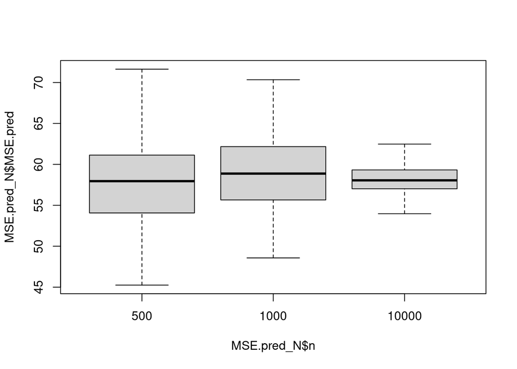

```r
MSE.pred_N = res.simu[(res.simu$SNR1==5 & res.simu$SNR2==5),]
boxplot(MSE.pred_N$MSE.pred~MSE.pred_N$n)
```

Quand n augmente, la variabilité diminue. Par contre, pas vraiment en moyenne.

- En fonction de SNR1

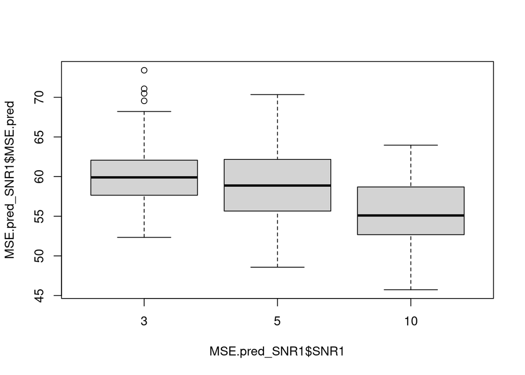

```r
MSE.pred_SNR1 = res.simu[(res.simu$n==1000 & res.simu$SNR2==5),]
boxplot(MSE.pred_SNR1$MSE.pred~MSE.pred_SNR1$SNR1)
```

Légère baisse en moyenne quand SNR1 augmente : ça va dans le bon sens

- En fonction de SNR2

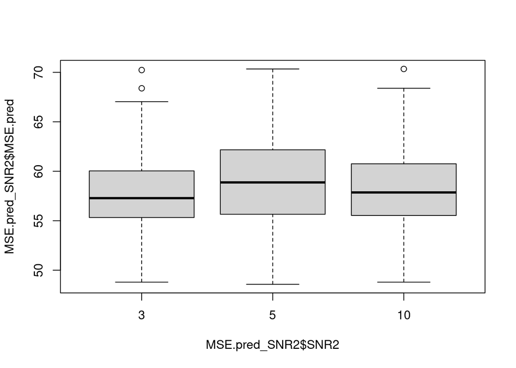

```r
MSE.pred_SNR2 = res.simu[(res.simu$n==1000 & res.simu$SNR1==5),]
boxplot(MSE.pred_SNR2$MSE.pred~MSE.pred_SNR2$SNR2)
```

Pas de différences notables : comportement étrange avec SNR2 (encore…)